# cohorte_estudio

Maximiliano Bustos

2026-04-19

## Datos

Vamos a usar el archivo *TP2_AID_2026_cohorte_estudio.csv*

```r
library(readr)
library(tidyverse)
cohorte_estudio <- read_delim("./dataTP2/TP2_AID_2026_cohorte_estudio.csv", delim = ",", trim_ws = TRUE)
spec(cohorte_estudio)
attach(cohorte_estudio)
```

## Q06 Media del puntaje final

```r
mean(puntaje_final)
```

```
## [1] 75.59829
```

## Q07 La mediana de la ansiedad

```r
median(ansiedad_score)
```

```
## [1] 21.535
```

## Q08 El mayor desvio entre horas_estudio, asistencia_pct, ansiedad_score y promedio_prev

ansiedad_score es el que tiene mayor desvío.

```r
#sd(c(horas_estudio, asistencia_pct, ansiedad_score, promedio_prev))
#cohorte_estudio[["horas_estudio"]] #, "asistencia_pct", "ansiedad_score", "promedio_prev"]]

print(sd(horas_estudio))
```

```
## [1] 2.842927
```

```r
print(sd(asistencia_pct))
```

```
## [1] 8.131467
```

```r
print(sd(ansiedad_score))
```

```
## [1] 10.54543
```

```r
print(sd(promedio_prev))
```

```
## [1] 9.054353
```

## Q09 Proporción de estudiantes aprobados

```r
table(aprobado)
```

```
## aprobado
##  Aprobado Reprobado
##       166        74
```

```r
sum(table(aprobado))
```

```
## [1] 240
```

```r
cantidad_aprobados = count(select(filter(cohorte_estudio, aprobado == "Aprobado"), aprobado))
total_alumnado = length(aprobado)

porcentaje_aprobado = cantidad_aprobados / total_alumnado

print(paste("El porcentaje de aprobados es: ", porcentaje_aprobado))
```

```
## [1] "El porcentaje de aprobados es:  0.691666666666667"
```

## Q10 La sede mas frecuente en la cohorte es

```r
names(which.max(table(sede)))
```

```
## [1] "Norte"
```

```r
max(table(sede))
```

```
## [1] 89
```

## Q11 La variable con correlacion positiva mas alta con puntaje_final

Son las horas semanales de estudio.

```r
cohorte_estudio_num <- cohorte_estudio %>% select_if(is.numeric)
cor(cohorte_estudio_num)
```

```
##                     horas_estudio asistencia_pct    sueno_hs ansiedad_score
## horas_estudio          1.00000000    0.146020142 -0.02110923    -0.19856748
## asistencia_pct         0.14602014    1.000000000  0.01465700    -0.12787669
## sueno_hs              -0.02110923    0.014656996  1.00000000    -0.03044217
## ansiedad_score        -0.19856748   -0.127876695 -0.03044217     1.00000000
## promedio_prev         -0.04096739   -0.009101774  0.02271094    -0.03257738
## trabajos_entregados    0.04708849    0.065556104  0.02250666    -0.01710456
## puntaje_final          0.47223766    0.285229776  0.07821104    -0.41692291
##                     promedio_prev trabajos_entregados puntaje_final
## horas_estudio        -0.040967394          0.04708849    0.47223766
## asistencia_pct       -0.009101774          0.06555610    0.28522978
## sueno_hs              0.022710940          0.02250666    0.07821104
## ansiedad_score       -0.032577378         -0.01710456   -0.41692291
## promedio_prev         1.000000000          0.46418765    0.41354682
## trabajos_entregados   0.464187647          1.00000000    0.32462159
## puntaje_final         0.413546821          0.32462159    1.00000000
```

## Q13

```r
set.seed(2026)
sd_poblacional <- 11.5 # conocido

# Simulamos datos donde la media real es 10.5, sd=11.5, n=40
# muestra <- rnorm(40, mean = 10.5, sd = sd_poblacional)

media_muestra <- mean(puntaje_final)
n <- length(puntaje_final)
media_hipotetica <- 72

# Estadístico z para H0: mu = 72 vs H1: mu > 72
error_estandar <- sd_poblacional / sqrt(n)

z_stat <- (media_muestra - media_hipotetica) / error_estandar
#p_valor <- 2 * (1 - pnorm(abs(z_stat)))  # prueba a dos colas
p_valor <- (1 - pnorm(abs(z_stat)))  # prueba a cola derecha.
p_valor
```

```
## [1] 6.256161e-07
```

## Q14

```r
set.seed(2026)
sd_poblacional <- sd(sueno_hs) # conocido

# Simulamos datos donde la media real es 10.5, sd=11.5, n=40
# muestra <- rnorm(40, mean = 10.5, sd = sd_poblacional)

media_muestra <- mean(sueno_hs)
n <- length(sueno_hs)
media_hipotetica <- 6.8

# Estadístico z para H0: mu = 72 vs H1: mu > 72
error_estandar <- sd_poblacional / sqrt(n)

z_stat <- (media_muestra - media_hipotetica) / error_estandar
p_valor <- 2 * (1 - pnorm(abs(z_stat)))  # prueba a dos colas

p_valor
```

```
## [1] 0.4045971
```

## Q15

```r
# Test de Shapiro-Wilk
shapiro_result <- shapiro.test(ansiedad_score)
print(shapiro_result)
```

```
##
##  Shapiro-Wilk normality test
##
## data:  ansiedad_score
## W = 0.95243, p-value = 4.318e-07
```

## Q16 Al aplicar Shapiro-Wilk sobre puntaje_final

```r
# Test de Shapiro-Wilk
shapiro_result <- shapiro.test(puntaje_final)
print(shapiro_result)
```

```
##
##  Shapiro-Wilk normality test
##
## data:  puntaje_final
## W = 0.99096, p-value = 0.1434
```

## Q17 En un Welch t-test para puntaje_final segun modalidad

El grupo A es la modalidad PRESENCIAL El grupo B es la modalidad VIRTUAL

```r
# ======================
#Prueba t sin asumir igualdad de varianzas (Welch's t-test)
# ======================
cat("=== Prueba t con varianzas diferentes (Welch's t-test) ===\n")
```

```
## === Prueba t con varianzas diferentes (Welch's t-test) ===
```

```r
puntaje_presencial <- select(filter(cohorte_estudio, modalidad == "Presencial"), puntaje_final)
puntaje_virtual <- select(filter(cohorte_estudio, modalidad == "Virtual"), puntaje_final)

# ----------------------
# Paso 1: Diferencia observada entre las medias
# ----------------------
puntaje_presencial <- as.numeric(unlist(puntaje_presencial))
puntaje_virtual <- as.numeric(unlist(puntaje_virtual))
media_A <- mean(puntaje_presencial)
media_B <- mean(puntaje_virtual)
diff_obs <- media_B - media_A


# varianzas muestrales de cada grupo
var_A <- var(puntaje_presencial)
var_B <- var(puntaje_virtual)


# error estándar sin asumir igualdad:
# Fórmula: SE = sqrt( var_A/n1 + var_B/n2 )
n1 <- length(puntaje_presencial)
n2 <- length(puntaje_virtual)

SE_welch <- sqrt(var_A/n1 + var_B/n2)
cat("Error estándar (Welch):", round(SE_welch, 2), "\n\n")
```

```
## Error estándar (Welch): 1.4
```

```r
# El estadístico t para Welch
t_stat_welch <- diff_obs / SE_welch
cat("Estadístico t (Welch):", round(t_stat_welch, 2), "\n\n")
```

```
## Estadístico t (Welch): -5.45
```

```r
grupo_A <- as.numeric(unlist(puntaje_presencial))
grupo_B <- as.numeric(unlist(puntaje_virtual))

# Varianzas diferentes (Welch) - Alternativa A > B
t.test( grupo_A, grupo_B, var.equal = FALSE, type="two.sample",alternative = "greater")
```

```
##
##  Welch Two Sample t-test
##
## data:  grupo_A and grupo_B
## t = 5.4513, df = 237.78, p-value = 6.248e-08
## alternative hypothesis: true difference in means is greater than 0
## 95 percent confidence interval:
##  5.319697      Inf
## sample estimates:
## mean of x mean of y
##  79.79556  72.16417
```

## Q18 En el test chi-cuadrado de independencia entre modalidad y aprobado, el p-valor es

```r
# Crear la tabla de contingencia
tabla_contingencia <- table(modalidad, aprobado)
print(tabla_contingencia)
```

```
##             aprobado
## modalidad    Aprobado Reprobado
##   Presencial       88        20
##   Virtual          78        54
```

```r
# Realizar el test de chi-cuadrado de independencia
test_independencia <- chisq.test(tabla_contingencia)
print(test_independencia)
```

```
##
##  Pearson's Chi-squared test with Yates' continuity correction
##
## data:  tabla_contingencia
## X-squared = 12.934, df = 1, p-value = 0.0003228
```

## Q19. Cuantos grados de libertad tendria nuestra distribucion chi cuadrado para el test si hubiera 4 modalidades de cursada (en vez de solo presencial y virtual) y hubiera 3 posibles çategorias.en aprobado

(f-1)*(c-1)= > (4-1)* (3-1) = 6

## Q20. Para el test chi-cuadrado entre sede y aprobado

```r
# Crear la tabla de contingencia
tabla_contingencia <- table(sede, aprobado)
print(tabla_contingencia)
```

```
##         aprobado
## sede     Aprobado Reprobado
##   Centro       43        20
##   Norte        67        22
##   Sur          56        32
```

```r
# Realizar el test de chi-cuadrado de independencia
test_independencia <- chisq.test(tabla_contingencia)
print(test_independencia)
```

```
##
##  Pearson's Chi-squared test
##
## data:  tabla_contingencia
## X-squared = 2.8467, df = 2, p-value = 0.2409
```

# Dixon y outliers

Usa la muestra chica de Dixon. Para la decision final, toma Qcrit = 0.338 (n = 15, alpha = 0.05).

```r
library(outliers)  # Para test de Grubbs y Dixon
dixon <- read_delim("./dataTP2/TP2_AID_2026_muestra_dixon.csv", delim = ",", trim_ws = TRUE)
```

## Q21. En TP2_AID_2026_muestra_dixon.csv, cual es el valor que aparece como candidato natural a outlier por el extremo alto?

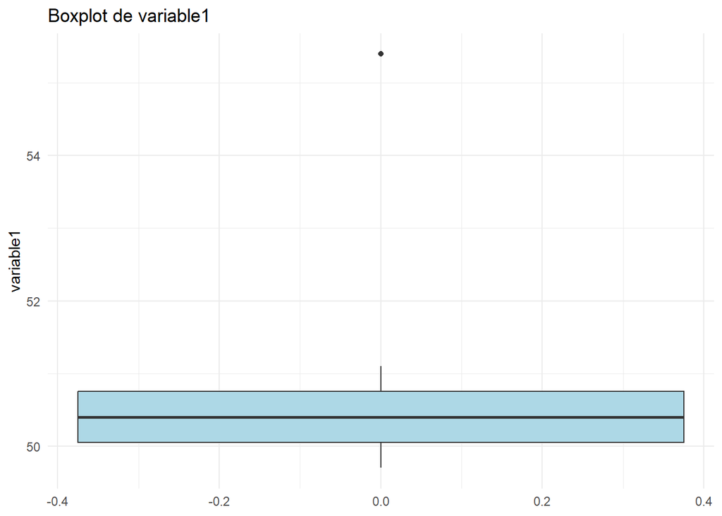

```r
ggplot(dixon, aes(y = medicion)) +
  geom_boxplot(fill = "lightblue") +
  labs(title = "Boxplot de variable1", y = "variable1") +
  theme_minimal()
```

```r
# Contar la cantidad de datos no nulos (sin NA)
sample_size <- sum(!is.na(dixon$medicion))

# Aplicar la prueba de Dixon solo si la muestra es <= 30
if (sample_size > 30) {
  submuestra <- sample(na.omit(dixon$medicion), 30)  # Seleccionar una submuestra de 30 elementos
  dixon_result <- dixon.test(submuestra)  # Aplicar test de Dixon
  print(dixon_result)
} else {
  dixon_result <- dixon.test(na.omit(dixon$medicion))  # Aplicar test directamente
  print(dixon_result)
}
```

```
##
##  Dixon test for outliers
##
## data:  na.omit(dixon$medicion)
## Q = 0.8, p-value < 2.2e-16
## alternative hypothesis: highest value 55.4 is an outlier
```

## Q22

```r
dixon_ordenado <- dixon[order(dixon$medicion),]

for (i in c(0:13)) {
  print((dixon_ordenado[2+i, 2] - dixon_ordenado[1+i, 2])/(max(dixon$medicion)-min(dixon$medicion)))
}
```

```
##     medicion
## 1 0.01754386
##     medicion
## 1 0.01754386
##     medicion
## 1 0.01754386
##     medicion
## 1 0.01754386
##     medicion
## 1 0.01754386
##     medicion
## 1 0.01754386
##     medicion
## 1 0.01754386
##     medicion
## 1 0.01754386
##     medicion
## 1 0.01754386
##     medicion
## 1 0.01754386
##     medicion
## 1 0.01754386
##     medicion
## 1 0.03508772
##     medicion
## 1 0.01754386
##   medicion
## 1 0.754386
```

## Q23. Tomando n = 15 y Qcrit = 0.338 para alpha = 0.05, cual es la conclusion?

```r
# Aplicar la prueba de Dixon solo si la muestra es <= 30
  submuestra <- sample(na.omit(dixon$medicion), 15)  # Seleccionar una submuestra de 15 elementos
  dixon_result <- dixon.test(submuestra)  # Aplicar test de Dixon
  print(dixon_result)
```

```
##
##  Dixon test for outliers
##
## data:  submuestra
## Q = 0.8, p-value < 2.2e-16
## alternative hypothesis: highest value 55.4 is an outlier
```

## Q24. El promedio de las mediciones excluyendo 55.4 es mas cercano a

```r
dixon_ordenado$medicion <- as.numeric(dixon_ordenado$medicion)
mean(dixon_ordenado$medicion[1:14])
```

```
## [1] 50.36429
```

# Bootstrap

## Q25. Usando la libreria boot, se quiere entender la variabilidad de la mediana de puntaje_final. Cual

seria un intervalo razonable 10 % a 90 % para la mediana haciendo un millon de replicas con el dataset original. El intervalo es mas cercano a:

```r
library(boot)

# Definir función para calcular la media del consumo de combustible
media_fn <- function(data, indices) {
  return(median(data[indices], na.rm = TRUE))
}

# Aplicar bootstrapping con 1 000 000 replicaciones
set.seed(2026)
boot_result <- boot(data = puntaje_final, statistic = media_fn, R = 1000000)
print(boot_result)
```

```
##
## ORDINARY NONPARAMETRIC BOOTSTRAP
##
##
## Call:
## boot(data = puntaje_final, statistic = media_fn, R = 1e+06)
##
##
## Bootstrap Statistics :
##     original     bias    std. error
## t1*    76.34 -0.1558674   0.8099005
```

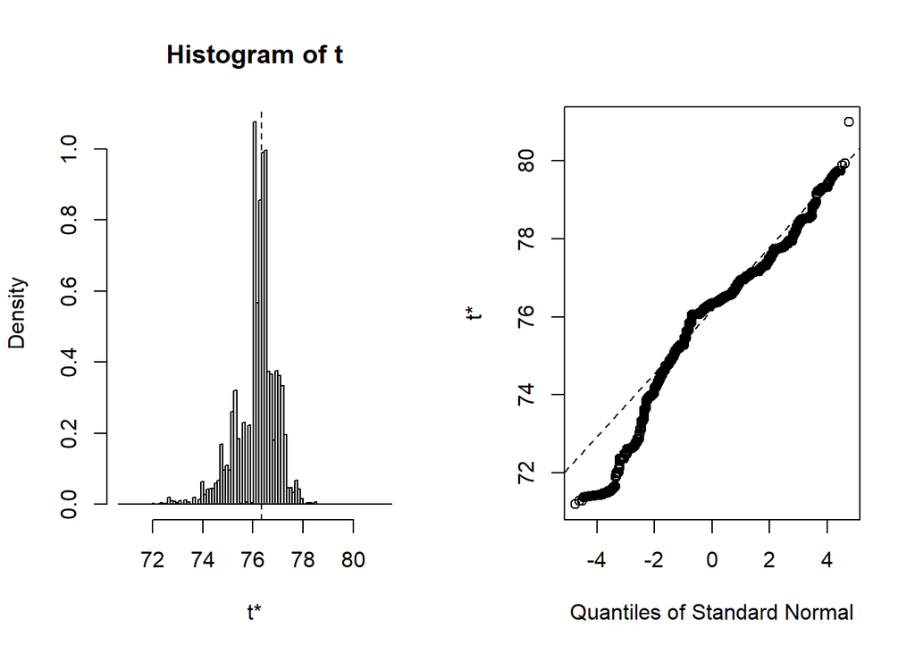

```r
plot(boot_result)
```

```r
boot.ci(boot_result,conf=0.80 ,type = "perc",)
```

```
## BOOTSTRAP CONFIDENCE INTERVAL CALCULATIONS
## Based on 1000000 bootstrap replicates
##
## CALL :
## boot.ci(boot.out = boot_result, conf = 0.8, type = "perc")
##
## Intervals :
## Level     Percentile
## 80%   (75.07, 77.08 )
## Calculations and Intervals on Original Scale
```

# E. Distancias

Estandarizando horas_estudio, asistencia_pct, ansiedad_score y promedio_prev sobre toda la cohorte,

```r
# Estandarización manual utilizando scale()
cohorte_estudio$horas_estudio_std <- scale(cohorte_estudio$horas_estudio)
cohorte_estudio$asistencia_pct_std <- scale(cohorte_estudio$asistencia_pct)
cohorte_estudio$ansiedad_score_std <- scale(cohorte_estudio$ansiedad_score)
cohorte_estudio$promedio_prev_std <- scale(cohorte_estudio$promedio_prev)

#summary(cohorte_estudio[,13:17])
cohorte_estudio[,14:17]
```

```
## # A tibble: 240 × 4
##    horas_estudio_std[,1] asistencia_pct_std[,1] ansiedad_score_std[,1]
##                    <dbl>                  <dbl>                  <dbl>
##  1                1.18                  -0.896                  -1.18
##  2                0.876                  0.199                   1.39
##  3               -0.355                 -1.14                   -0.186
##  4                0.820                 -0.0281                 -0.521
##  5               -1.09                   1.24                    0.222
##  6                0.257                  0.260                   0.307
##  7                1.57                   0.327                   0.415
##  8                0.127                 -0.631                  -0.888
##  9                0.658                  1.78                   -1.22
## 10                0.0393                -0.0662                 -1.08
## # ℹ 230 more rows
## # ℹ 1 more variable: promedio_prev_std <dbl[,1]>
```

## Q30. Cual es la distancia euclidea entre E014 y E120? Responde con dos decimales.

```r
x <- cohorte_estudio[14,14:17]
y <- cohorte_estudio[120,14:17]

round(sqrt(sum((x - y)^2)),2)
```

```
## [1] 1.69
```

## Q31. Con esas mismas cuatro variables estandarizadas, cual es la distancia Manhattan entre E014 y

E120?

```r
round(sum(abs(x - y)),2)
```

```
## [1] 2.92
```

## Q32. Con esas mismas cuatro variables estandarizadas, la distancia Chebyshev entre E014 y E120 es

mas cercana a

```r
round(max(abs(x - y)),2)
```

```
## [1] 1.25
```

## Q35. Sean los siguientes vectores en R4

a = (8, 16, 8, 16), b = (2, 5, 2, 5), c = (4, 1, 4, 1)

```r
a <- c(8, 16, 8, 16)
b <- c(2, 5, 2, 5)
c <- c(4, 1, 4, 1)

cos_sim <- function(x, y) {
  sum(x * y) / (sqrt(sum(x^2)) * sqrt(sum(y^2)))
}


ab <- cos_sim(a,b)
ac <- cos_sim(a,c)
bc <- cos_sim(b,c)
```